# Загрузка и первое знакомство с данными

Для начала загружаем данные и проверим их на наличие Null-значений

```python
import pandas as pd
import numpy as np

white_wines = pd.read_csv('/Users/daniilbelokonev/Downloads/wine+quality/winequality-white.csv', sep=';')
red_wines = pd.read_csv('/Users/daniilbelokonev/Downloads/wine+quality/winequality-red.csv', sep=';')
```

Перед тем, как начать полное исследование наборов данных, стоит изучить вообще, что за характеристики есть у вина. Это поможет нам лучше понять набор данных, чтобы в последствии возможно отбросить те или иные характеристики (если это будет нужно или необходимо!!!)

```python
columns = white_wines.columns
```

- **fixed acidity (ру. фиксированная кислотность)** - это характеристика, определяемая содержанием нелетучих кислот, таких как винная, яблочная и лимонная. Она важна для сбалансированности вкуса вина, придает ему свежесть и участвует в формировании его структуры. Оптимальный уровень фиксированной кислотности важен для создания гармоничного вина. Слишком высокая кислотность может сделать вино слишком резким, а слишком низкая – "безжизненным".
- **volatile acidity (ру. летучая кислотность)** - это показатель содержания в вине кислот, которые могут испаряться с водяным паром. В основном это уксусная кислота и ее эфиры, которые придают вину неприятный запах и вкус, особенно в высоких концентрациях. В небольших количествах летучие кислоты могут придавать вину сложность и пикантность, но при избытке они становятся дефектом, ухудшая вкус и аромат.
- **citric acid (ру. лимонная кислота)** - используется для корректировки кислотности, улучшения вкуса и предотвращения помутнений, связанных с железом. Хотя лимонная кислота присутствует в винограде в небольших количествах, её часто добавляют в вино, особенно на завершающих этапах производства, для достижения желаемой кислотности и вкусового баланса. Однако, стоит учитывать, что лимонная кислота может подвергаться молочнокислому брожению, в результате которого образуется уксусная кислота, придающая вину неприятный уксусный запах.
- **residual sugar (ру. остаточный сахар)** - это количество сахара, которое остается после завершения процесса брожения, когда дрожжи перерабатывают сахар в спирт. Этот остаточный сахар определяет сладость вина и может варьироваться в зависимости от типа вина и процесса его производства. Чем больше остаточного сахара, тем слаще вино.
- **chlorides (ру. хлориды)** - присутствуют в виде хлоридов кальция и натрия. Эти соединения, хотя и являются естественной частью химического состава вина, в повышенных концентрациях могут влиять на его вкус, стабильность и даже вызывать коррозию оборудования. Хлориды, в частности хлорид кальция, могут придавать вину более мягкий, округлый и сладковатый вкус.
- **free sulfur dioxide (ру. свободный диоксид серы)** - это консервант, который используется для защиты вина от окисления и развития бактерий. Он также помогает сохранить свежесть, фруктовые ароматы и вкусовые качества вина. При правильном использовании диоксид серы не должен изменять вкус и аромат вина. Однако, избыток диоксида серы может придать вину неприятный запах и ухудшить его вкус.
- **total sulfur dioxide (ру. общий диоксид серы)** - это суммарное количество диоксида серы (SO2), как добавленного в процессе производства, так и образовавшегося в результате естественных процессов брожения. Он является консервантом, предотвращающим окисление и порчу вина, а также защищающим его от бактерий и дрожжей.
- **density (ру. плотность)** - это характеристика, описывающая его "тело" или текстуру, то есть насколько густым и насыщенным оно ощущается на вкус. Плотность вина зависит от содержания в нем спирта, сахара и глицерина, а также других экстрактивных веществ. Плотные вина кажутся более насыщенными, полнотелыми и богатыми на вкус, в то время как более легкие вина кажутся более освежающими и менее концентрированными.
- **pH (ру. не переводится)** - это показатель кислотности вина, который определяет концентрацию ионов водорода. Он измеряется по шкале от 0 до 14, где 7 - нейтральный, ниже 7 - кислый, выше 7 - щелочной. В вине pH обычно находится в диапазоне от 3 до 4, при этом белые вина обычно более кислые, чем красные. Более низкие значения pH повышают стабильность вина, делая его менее подверженным бактериальным проблемам и окислению.
- **sulphates (ру. сульфаты)** - это соединения серы, которые используются в виноделии в качестве консервантов и антиоксидантов. Они предотвращают окисление вина и подавляют рост нежелательных микроорганизмов, таких как бактерии и дикие дрожжи. Все вина содержат сульфиты, как естественный побочный продукт ферментации, так и добавленные в процессе производства.
- **alcohol (ру. спирт)** - этанол, образуется в результате брожения виноградного сока. Его количество (крепость) влияет на вкус, структуру и общее восприятие вина, а также на его физиологическое воздействие. Слишком много или слишком мало алкоголя может нарушить баланс вина, делая его несбалансированным и неприятным.
- **quality (ру. качество)** - таргет переменная, описывающая качество вина

К сожалению, мы не являемся знатоками в вине (даже никогда пробовали), но из всего выше перечисленного можно выявить некоторые мысли и гипотезы, которые мы вспослдствии проверим.

Это все гипотезы и мы их проверим чуть позже.

1. фиксированная кислотность - слишком высокие показатели данной характеристики должны снижать качество вина, но, при этом, и слишком низкие показатели данной характеристики тоже должны снижать качество вина (нужен баланс)
2. летучая кислотность - чем ниже показатель, тем лучше вино
3. лимонная кислота - в нашем случае у нас нет информации о том, подверглась ли лимонная кислота молочнокислому брожению или нет, поэтому это учитывать не будем, но в идеале, конечно, и это стоит учитывать. Однако, прямого влияния на качетсво вина лимонная кислота не показывает, так что смеем предположить, что тут нужно просто соблюдать баланс
4. остаточный сахар - прямого влияния остаточных сахар тоже не проявляет на уровень качества вина
5. хлориды - высокое сожержание отрицательно влияет на качество вина
6. свободный диоксид серы - высокое содержание отриуательно влияет на качество вина
7. общий диоксид серы - должен быть в оптимальном диапазоне: недостаток ведет к окислению, избыток - к неприятному запаху
8. плотность - прямого влияния на качество вина не замечено (на вкус да, но на качество нет)
9. pH - чем ниже показатель, тем лучше
10. сульфаты - в умеренных количествах улучшают стабильность вина, но избыток может придать неприятный химический привкус (нужен баланс)
11. спирт - слишком высокие показатели данной характеристики должны снижать качество вина, но, при этом, и слишком низкие показатели данной характеристики тоже должны снижать качество вина (нужен баланс)

Это примерный первый взгляд на характеристики вина, в дальнейшем мы более подробно посмотрим на то, как влияют эти характеристики на таргет переменную (и влияют ли вообще)

```python
# Нвши данные
print('White wines')
display(white_wines.head())
print('\n Red wines')
display(red_wines.head())
```

```
White wines
```

|  | fixed acidity | volatile acidity | citric acid | residual sugar | chlorides | free sulfur dioxide | total sulfur dioxide | density | pH | sulphates | alcohol | quality | wine type |
| --- | --- | --- | --- | --- | --- | --- | --- | --- | --- | --- | --- | --- | --- |
| 0 | 7.0 | 0.27 | 0.36 | 20.7 | 0.045 | 45.0 | 170.0 | 1.0010 | 3.00 | 0.45 | 8.8 | 6 | white |
| 1 | 6.3 | 0.30 | 0.34 | 1.6 | 0.049 | 14.0 | 132.0 | 0.9940 | 3.30 | 0.49 | 9.5 | 6 | white |
| 2 | 8.1 | 0.28 | 0.40 | 6.9 | 0.050 | 30.0 | 97.0 | 0.9951 | 3.26 | 0.44 | 10.1 | 6 | white |
| 3 | 7.2 | 0.23 | 0.32 | 8.5 | 0.058 | 47.0 | 186.0 | 0.9956 | 3.19 | 0.40 | 9.9 | 6 | white |
| 4 | 7.2 | 0.23 | 0.32 | 8.5 | 0.058 | 47.0 | 186.0 | 0.9956 | 3.19 | 0.40 | 9.9 | 6 | white |

```
 Red wines
```

|  | fixed acidity | volatile acidity | citric acid | residual sugar | chlorides | free sulfur dioxide | total sulfur dioxide | density | pH | sulphates | alcohol | quality | wine type |
| --- | --- | --- | --- | --- | --- | --- | --- | --- | --- | --- | --- | --- | --- |
| 0 | 7.4 | 0.70 | 0.00 | 1.9 | 0.076 | 11.0 | 34.0 | 0.9978 | 3.51 | 0.56 | 9.4 | 5 | red |
| 1 | 7.8 | 0.88 | 0.00 | 2.6 | 0.098 | 25.0 | 67.0 | 0.9968 | 3.20 | 0.68 | 9.8 | 5 | red |
| 2 | 7.8 | 0.76 | 0.04 | 2.3 | 0.092 | 15.0 | 54.0 | 0.9970 | 3.26 | 0.65 | 9.8 | 5 | red |
| 3 | 11.2 | 0.28 | 0.56 | 1.9 | 0.075 | 17.0 | 60.0 | 0.9980 | 3.16 | 0.58 | 9.8 | 6 | red |
| 4 | 7.4 | 0.70 | 0.00 | 1.9 | 0.076 | 11.0 | 34.0 | 0.9978 | 3.51 | 0.56 | 9.4 | 5 | red |

```python
# Получаем немного больше инфомрации о датасетах + посмотрим на количество Null-значений
print('White wines')
display(white_wines.info())
display(white_wines.isnull().sum())

print('\n Red wines')
display(red_wines.info())
display(red_wines.isnull().sum())
```

```
White wines
<class 'pandas.core.frame.DataFrame'>
RangeIndex: 4898 entries, 0 to 4897
Data columns (total 13 columns):
 #   Column                Non-Null Count  Dtype
---  ------                --------------  -----
 0   fixed acidity         4898 non-null   float64
 1   volatile acidity      4898 non-null   float64
 2   citric acid           4898 non-null   float64
 3   residual sugar        4898 non-null   float64
 4   chlorides             4898 non-null   float64
 5   free sulfur dioxide   4898 non-null   float64
 6   total sulfur dioxide  4898 non-null   float64
 7   density               4898 non-null   float64
 8   pH                    4898 non-null   float64
 9   sulphates             4898 non-null   float64
 10  alcohol               4898 non-null   float64
 11  quality               4898 non-null   int64
 12  wine type             4898 non-null   object
dtypes: float64(11), int64(1), object(1)
memory usage: 497.6+ KB
```

```
None
```

```
fixed acidity           0
volatile acidity        0
citric acid             0
residual sugar          0
chlorides               0
free sulfur dioxide     0
total sulfur dioxide    0
density                 0
pH                      0
sulphates               0
alcohol                 0
quality                 0
wine type               0
dtype: int64
```

```
 Red wines
<class 'pandas.core.frame.DataFrame'>
RangeIndex: 1599 entries, 0 to 1598
Data columns (total 13 columns):
 #   Column                Non-Null Count  Dtype
---  ------                --------------  -----
 0   fixed acidity         1599 non-null   float64
 1   volatile acidity      1599 non-null   float64
 2   citric acid           1599 non-null   float64
 3   residual sugar        1599 non-null   float64
 4   chlorides             1599 non-null   float64
 5   free sulfur dioxide   1599 non-null   float64
 6   total sulfur dioxide  1599 non-null   float64
 7   density               1599 non-null   float64
 8   pH                    1599 non-null   float64
 9   sulphates             1599 non-null   float64
 10  alcohol               1599 non-null   float64
 11  quality               1599 non-null   int64
 12  wine type             1599 non-null   object
dtypes: float64(11), int64(1), object(1)
memory usage: 162.5+ KB
```

```
None
```

```
fixed acidity           0
volatile acidity        0
citric acid             0
residual sugar          0
chlorides               0
free sulfur dioxide     0
total sulfur dioxide    0
density                 0
pH                      0
sulphates               0
alcohol                 0
quality                 0
wine type               0
dtype: int64
```

Как можем заметить, Null-значений тут не встречается, поэтому можно переходить дальше. Стоит изучить данные на наличие выбросов или аномалий

```python
# Взглянем на униккальные значения столбцов
for column in columns:
    print(f'\nКолонка: {column}')
    print(white_wines[column].unique())
```

```
Колонка: fixed acidity
[ 7.    6.3   8.1   7.2   6.2   8.6   7.9   6.6   8.3   7.4   6.5   6.4
  6.8   7.6   6.9   8.5   5.8   7.3   6.7   6.    7.1   6.1   7.5   9.8
  5.5   5.9   7.8   5.7   8.2   5.6   5.2   8.4  10.2   7.7   5.3   5.4
  9.1   5.    8.   10.    5.1   9.2   9.    8.8   8.7   4.8  10.3   9.4
  9.6   9.3   8.9   9.7  10.7  14.2   9.9   9.5  11.8   4.6   6.15  4.5
  7.15  6.45  4.2   4.9   4.7   3.8   4.4   3.9 ]

Колонка: volatile acidity
[0.27  0.3   0.28  0.23  0.32  0.22  0.18  0.16  0.42  0.17  0.48  0.66
 0.34  0.31  0.26  0.67  0.25  0.24  0.14  0.12  0.39  0.33  0.45  0.46
 0.19  0.2   0.21  0.38  0.47  0.35  0.54  0.43  0.44  0.265 0.36  0.305
 0.13  0.41  0.485 0.425 0.37  0.255 0.595 0.29  0.53  0.15  0.57  0.4
 0.245 0.685 0.495 0.64  0.52  0.115 0.58  0.585 0.59  0.6   0.55  0.125
 0.1   0.145 0.335 0.365 0.905 0.49  0.155 0.51  0.62  0.345 0.475 0.56
 0.235 0.105 0.5   0.11  0.225 0.395 0.655 0.205 0.415 0.705 0.08  0.68
 0.275 0.61  0.135 0.165 0.85  0.185 0.325 0.445 0.545 0.91  0.71  1.005
 0.385 0.76  0.93  0.295 0.695 0.815 0.285 0.175 0.615 0.315 0.965 0.375
 0.74  0.78  0.215 0.435 0.75  0.085 0.73  0.65  0.455 1.1   0.555 0.09
 0.63  0.69  0.785 0.405 0.355]

Колонка: citric acid
[0.36 0.34 0.4  0.32 0.16 0.43 0.41 0.37 0.62 0.38 0.04 0.48 0.42 0.14
 0.35 0.39 0.2  0.23 0.26 0.27 0.31 0.25 0.29 0.33 0.59 0.15 0.24 0.07
 0.03 0.13 0.28 0.46 0.3  0.61 0.63 0.66 0.54 0.5  0.   0.47 0.56 0.22
 0.67 0.18 0.45 0.44 0.88 0.21 0.08 0.49 0.58 0.7  0.6  0.51 0.1  0.19
 0.12 0.09 0.53 0.02 0.65 0.17 0.71 0.06 0.68 0.72 0.69 1.66 0.57 0.05
 0.52 1.   0.01 0.74 0.81 0.55 0.64 0.73 0.99 0.78 0.79 0.82 0.8  1.23
 0.86 0.11 0.91]

Колонка: residual sugar
[20.7   1.6   6.9   8.5   7.    1.5   1.45  4.2   1.2  19.25  1.1   7.5
  2.9   1.7   1.3   9.    1.    8.7   2.   10.4   2.05 14.95  5.4  17.95
  2.5   7.4   1.4   4.4   5.    0.9  11.9  12.4   4.6   4.9   6.4   2.1
 10.1   7.8   4.8   8.8  16.    6.1   8.2  11.8  11.   13.3   1.8  15.9
 10.5  13.5   9.6  12.1  18.9  14.4  16.5  18.75  9.2   3.3   5.7  12.2
  6.85  7.6   2.8   2.7  13.1  15.8   8.1  15.7   1.9   2.2   4.3   5.2
  4.1   8.   10.2  14.   14.5  13.    2.4   8.95  9.85  0.8   4.55 17.7
  5.1  12.9   5.5  22.    9.4   3.8   3.6   3.5  16.1  13.2  13.9   2.3
 11.6   8.3   6.2   9.7   5.3  17.5   9.5  17.8  10.3  14.3  15.55 13.7
```

[output cut: 209 more lines]

```
 11.5        11.8        12.1        11.1         8.5        12.5
 11.9        12.2        12.9        13.9        14.         13.5
 13.3        13.2        13.7        13.4        13.          8.
 13.1        13.6         8.4        14.2        11.94       12.89333333
 11.46666667 10.98       10.03333333 11.43333333 10.53333333  9.53333333
 10.93333333 11.36666667 11.33333333 11.06666667  9.73333333 11.05
  9.75       11.35        9.55       10.55       11.45       14.05
 12.33333333 12.75       13.8        12.15       13.05       11.26666667
 10.56666667 11.73333333 11.75       10.65       10.96666667 10.13333333
 10.15       10.46666667 11.63333333 12.25       11.85       11.65
 13.55       13.13333333 11.95       12.06666667 11.55        9.63333333
 12.05      ]

Колонка: quality
[6 5 7 8 4 3 9]
```

```
Колонка: fixed acidity
```

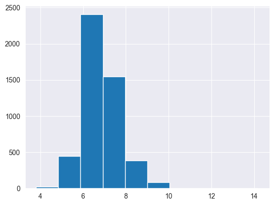

```
Колонка: volatile acidity
```

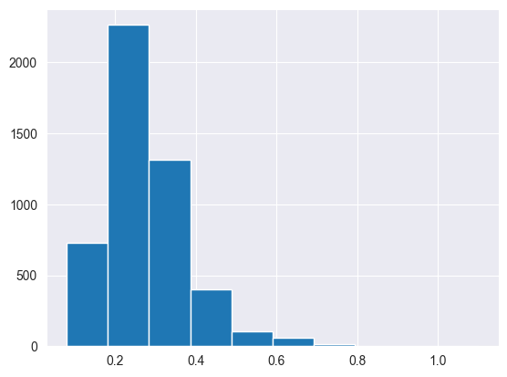

```
Колонка: citric acid
```

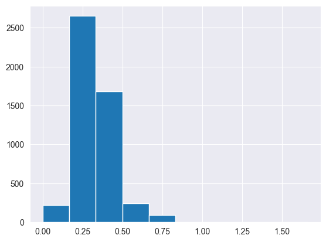

```
Колонка: residual sugar
```

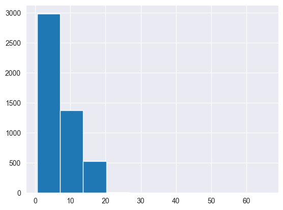

```
Колонка: chlorides
```

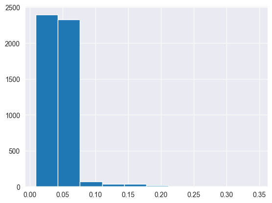

```
Колонка: free sulfur dioxide
```

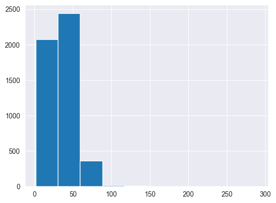

```
Колонка: total sulfur dioxide
```

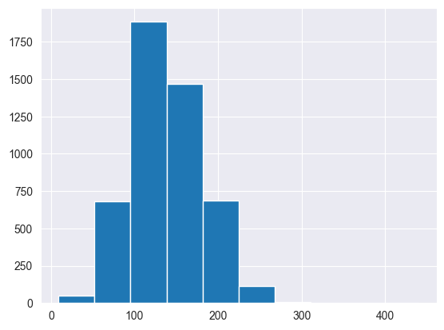

```
Колонка: density
```

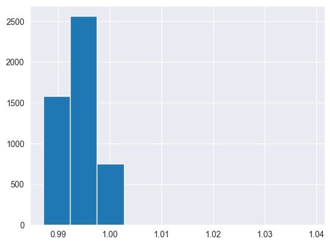

```
Колонка: pH
```

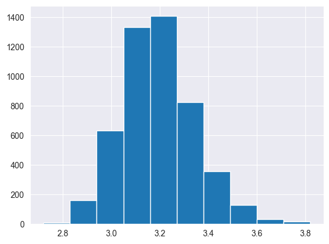

```
Колонка: sulphates
```

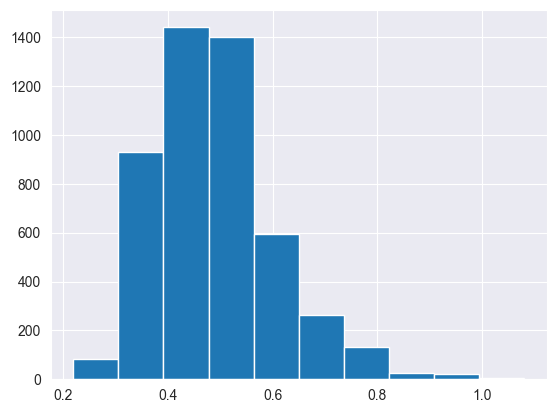

```
Колонка: alcohol
```

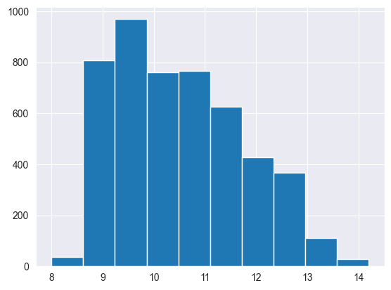

```
Колонка: quality
```

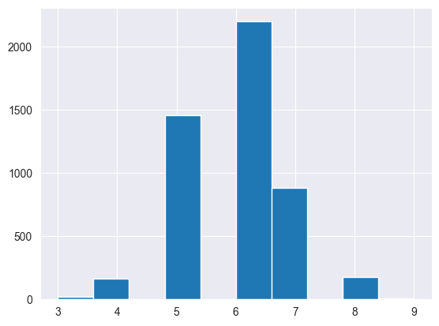

```python
import matplotlib.pyplot as plt
import seaborn as sns

# Посмотрим на распределение данных
for column in columns:
    print(f'\nКолонка: {column}')
    plt.hist(white_wines[column])
    plt.show()
```

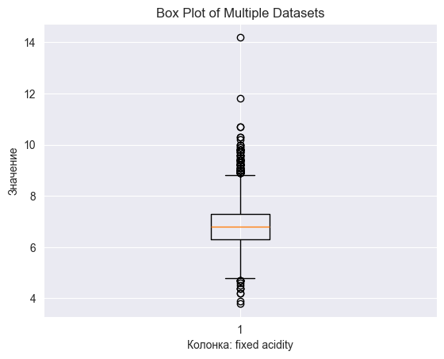

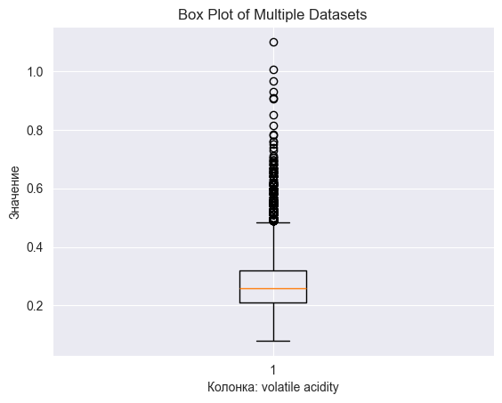

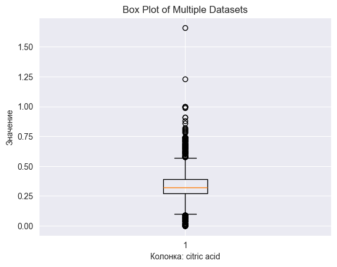

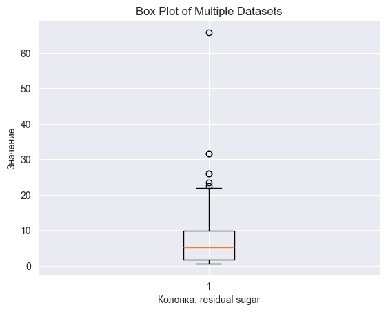

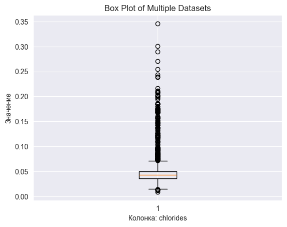

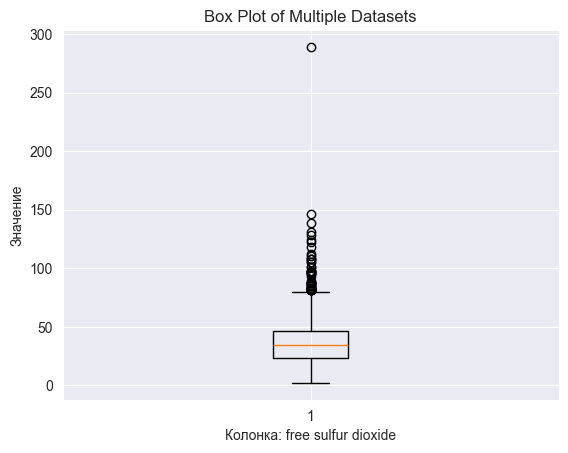

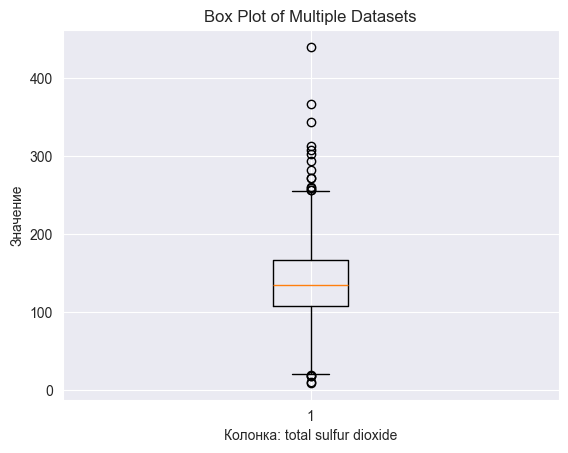

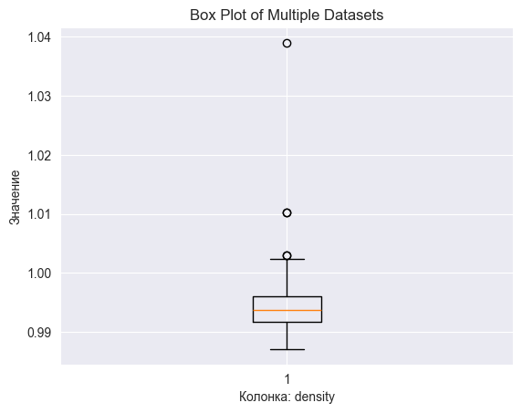

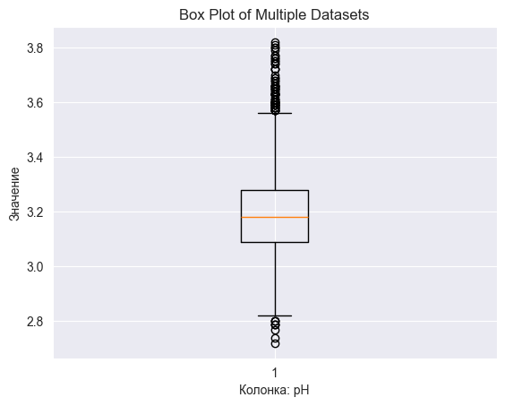

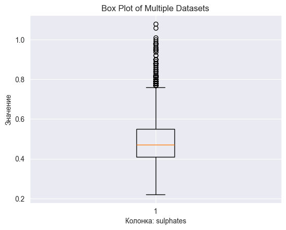

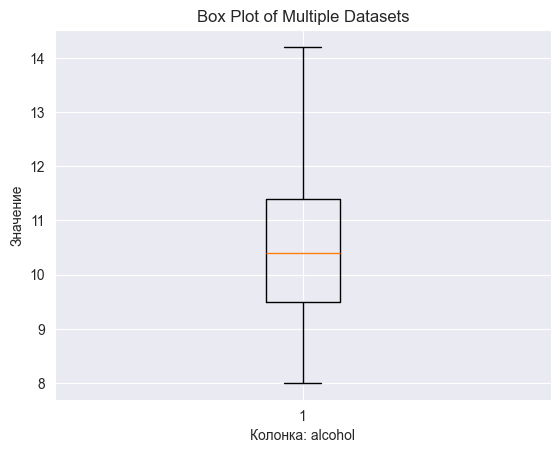

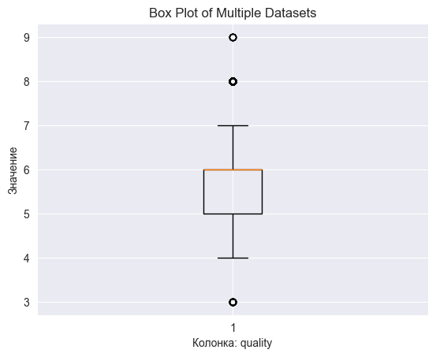

```python
# Посмотрим на boxplot графики для наших атрибутов
for column in columns:
    plt.boxplot(white_wines[column])
    plt.xlabel(f'Колонка: {column}')
    plt.ylabel("Значение")
    plt.title("Box Plot of Multiple Datasets")

    plt.show()
```

```python
# Немного статистики
# посмотрим на z-score для каждого атрибута
from scipy.stats import zscore

for column in columns:
    z_scores = zscore(white_wines_copy[column])
    outliers_count = (abs(z_scores) > 3).sum()
    print(f'Колонка: {column}, количество выбросов: {outliers_count}')
```

[output not shown]

Как можно заметить: данные и правда имеют выбросы, но бывают и такие вина, в которых встерчаются аномальные характеристики и при этом они являются особенно премиальными и дорогими видами данного напитка.